# Reporte de Copa KC Setiembre 2022

> Reporte de Mazos de la comunidad LATAM usados en la primera fase de la KC Cup en YuGiOh! Duel Links

[figure not shown]

## Un poco de contexto

[Yu-Gi-Oh! Duel Links](https://www.konami.com/yugioh/duel_links/en/) es un videojuego de cartas coleccionables digital con mecánica free-to-play con microtransacciones desarrollado por Konami para Windows descargable con Steam, iOS y Android. Primero se lanza en Japón el 17 de noviembre de 2016 y se libera a nivel mundial el 11 de enero de 2017. En el lore del juego, Seto Kaiba a través de su corporación crea una realidad virtual llamada "Duel World" para reunir a los mejores duelistas para que puedan competir donde a lo largo del tiempo acompañan los personajes de las diferentes sagas y spin-offs.

Por medio de ello realiza cada cierto tiempo la copa Kaiba Corporation para demostrar quien es el mejor duelista del planeta.

[figure not shown]

Es un sistema de ranking que consta de 2 fases, en resumen la fase 1 recompensa gemas que son la moneda del juego y en la fase 2 da premio al 1er lugar para clasificar al mundial de yugioh pero no recompensa gemas. Por lo que la comunidad normalmente prioriza la fase 1 que te da recursos para la cuenta.

## Conociendo los datos

**1. id** registro único para identificar usuario.

**2. usuario** Es el jugador, en la base de datos es único y no deja reportar si jugó en varias cuentas, es criterio de exclusión de la base de datos si se reporta que jugó varias cuentas/decks.

**3. deck** Arquetipo usado.

**4. skill** Habilidad usada en el deck.

**5. wins** Total de victorias conseguidas en el mes reportado hasta el momento que llegó al ndmax, por eventos separados el juego no contabiliza.

**6. ndmax** Fecha que llegó al rango máximo.

**7. Los booleanos** Comprueba si el usuario compartió su deck en qué server en concreto.  
- zerotg = ZeroTG  
- zephra = ZephraCarl  
- bryan = [Bryan Norén](https://www.youtube.com/c/BryanNor%C3%A9n)  
- xenoblur = [Xenoblur](https://www.youtube.com/c/XenoBlur)

## Pre-procesamiento de datos

Un poco de spam de código, **cargando datos...**

[figure not shown]

```
Conexión exitosa.
```

```
Versión del servidor de PostgreSQL: ('PostgreSQL 13.8, compiled by Visual C++ build 1914, 64-bit',)
```

```
Tabla creada
```

```
Registros insertados hasta el 19-09-2022
```

**Base de datos cargada**

[figure not shown]

### Conteo de observaciones y variables

```
En total hay 362 usuarios registrados
```

```
# Mostrando tabla
df
```

|  | id | usuario | deck | skill | wins | ndmax | zerotg | zephra | bryan | xenoblur |
| --- | --- | --- | --- | --- | --- | --- | --- | --- | --- | --- |
| 0 | 1 | 0953 | Tech Genus | Control de Vuelo | 62.0 | 2022-09-06 | True | False | False | False |
| 1 | 2 | 0986 | Rose Dragon | Conjuro de Rosas | 102.0 | 2022-09-06 | True | False | False | False |
| 2 | 4 | 6100 | Rose Dragon | Conjuro de Rosas | 45.0 | 2022-09-06 | True | False | False | False |
| 3 | 5 | 4074 | Elemental Heros | Duelo Favorito | 163.0 | 2022-09-06 | True | False | False | False |
| 4 | 8 | 4162 | Meklord | Refinamiento Meklord | 92.0 | 2022-09-07 | True | False | False | False |
| ... | ... | ... | ... | ... | ... | ... | ... | ... | ... | ... |
| 357 | 368 | 9193 | Galaxy-Eyes | Galaxia XYZ | 87.0 | 2022-09-18 | False | False | False | True |
| 358 | 369 | 9338 | Deskbots | Pasa a la acción Invocación por Péndulo | NaN | 2022-09-18 | False | False | False | True |
| 359 | 345 | 1737 | Railway | Tren Imparable | NaN | 2022-09-18 | True | True | False | False |
| 360 | 356 | 0731 | Elemental Heros | Duelo Favorito | 61.0 | 2022-09-18 | False | True | False | False |
| 361 | 358 | 1246 | Qliphort | Mundo Sonriente | NaN | 2022-09-18 | False | True | False | False |

362 rows × 10 columns

## Visualización de los datos

### Registro de la comunidad

```
Tabla de cuántos usuarios reportaron sus ndmax a los servers
```

|  | Servers | Total |
| --- | --- | --- |
| 0 | zerotg | 187 |
| 1 | zephra | 112 |
| 2 | bryan | 111 |
| 3 | xenoblur | 61 |

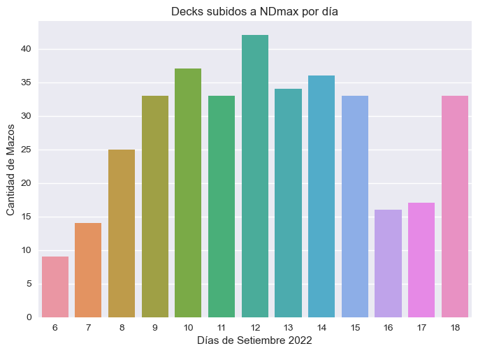

```
En promedio suelen tardar hasta el día 12 para llegar a ndMAX
```

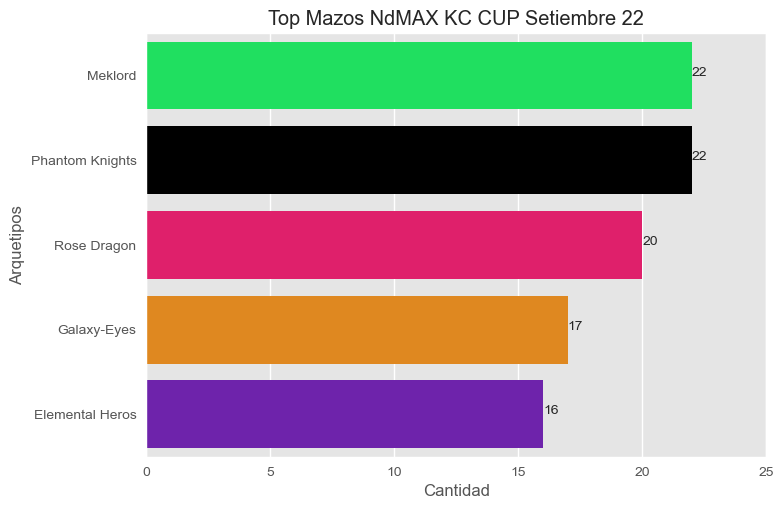

```
De 72 arquetipos distintos este el top 5
```

### Habilidades que usaron los Top Decks

|  | deck | skill | total |
| --- | --- | --- | --- |
| 68 | Meklord | Refinamiento Meklord | 22 |

|  | deck | skill | total |
| --- | --- | --- | --- |
| 78 | Phantom Knights | Estrategia Fantasma | 15 |
| 79 | Phantom Knights | La Orden de los Caballeros Fantasma | 7 |

|  | deck | skill | total |
| --- | --- | --- | --- |
| 87 | Rose Dragon | Conjuro de Rosas | 20 |

|  | deck | skill | total |
| --- | --- | --- | --- |
| 40 | Galaxy-Eyes | Galaxia XYZ | 16 |
| 39 | Galaxy-Eyes | Fotónico de la Galaxia | 1 |

|  | deck | skill | total |
| --- | --- | --- | --- |
| 26 | Elemental Heros | Duelo Favorito | 16 |

> Se aprecia que los arquetipos juegan su versión óptima una sola habilidad. Pocos se ven que pueden jugar varias skills

### Arquetipos con mayor diversidad de habilidades

|  | deck | total |
| --- | --- | --- |
| 34 | Heros | 5 |
| 41 | Magnet Warrios | 5 |
| 0 | Abyss Actor | 3 |
| 52 | Qliphort | 3 |
| 32 | Harpies | 3 |
| 15 | Dark Magician | 3 |
| 24 | Fluffal | 3 |
| 48 | Necroz | 3 |
| 58 | Shiranui | 3 |
| 65 | Tech Genus | 3 |
| 21 | Evil Eye | 3 |

```
su lista de Habilidades del top 2
```

|  | deck | skill | total |
| --- | --- | --- | --- |
| 48 | Heros | Alianza de Héroes | 3 |
| 49 | Heros | Fusión Milagrosa | 1 |
| 50 | Heros | Héroe Herido | 1 |
| 51 | Heros | Maestro de Fusión | 1 |
| 52 | Heros | Robar sentido Viento | 3 |
| 60 | Magnet Warrios | Aumento de LP alfa | 1 |
| 61 | Magnet Warrios | Duplicar Nivel | 1 |
| 62 | Magnet Warrios | Guerreros Fósiles | 2 |
| 63 | Magnet Warrios | Lectura Mental | 1 |
| 64 | Magnet Warrios | Robo del Destino | 2 |

### Habilidades que se repiten en distintos arquetipos

```
Esta tabla representa la skill que se encuentra en distintos arquetipos
```

|  | skill | total |
| --- | --- | --- |
| 70 | Robo del Destino | 10 |
| 57 | Precognición | 3 |
| 4 | Aumento de LP alfa | 3 |
| 5 | Barrera de Luz | 3 |
| 35 | La Impactante actuación de Sylvio | 3 |
| 68 | Robar sentido Viento | 3 |

```
Tabla de todos los mazos que usan Robo del Destino
```

|  | deck | skill | total |
| --- | --- | --- | --- |
| 20 | Dark Magician | Robo del Destino | 7 |
| 25 | Dragunity | Robo del Destino | 1 |
| 43 | Gravekeepers | Robo del Destino | 3 |
| 45 | Harpies | Robo del Destino | 1 |
| 58 | Lunalight | Robo del Destino | 6 |
| 64 | Magnet Warrios | Robo del Destino | 2 |
| 89 | Satellarknights | Robo del Destino | 13 |
| 92 | Shiranui | Robo del Destino | 4 |
| 96 | Super Quant | Robo del Destino | 1 |
| 111 | Yosenjus | Robo del Destino | 2 |

> Hace referencia al anime cuando en sus partidas difíciles Yugi roba la carta que necesita para ganar el duelo.

[figure not shown]

```
Reporte finalizado, terminar conexión.
```

[figure not shown]

## Información de sesión

**Click to view session information**

```
-----
decouple            NA
matplotlib          3.5.3
numpy               1.23.2
pandas              1.4.4
pyprojroot          0.2.0
requests            2.28.1
seaborn             0.12.0
session_info        1.0.0
sqlalchemy          1.4.40
-----
```

**Click to view modules imported as dependencies**

[output not shown]

[output cut: 10 more lines]

[output not shown]

```
-----
IPython             8.4.0
jupyter_client      7.3.5
jupyter_core        4.11.1
jupyterlab          3.4.5
notebook            6.4.12
-----
Python 3.10.6 | packaged by conda-forge | (main, Aug 22 2022, 20:30:19) [MSC v.1929 64 bit (AMD64)]
Windows-10-10.0.19043-SP0
-----
Session information updated at 2022-09-19 17:05
```

[figure not shown]